# NDFS Synthesis Manuscript: Chlorophyll analysis

### Model with lag terms

Now, we’ll try to deal with the residual autocorrelation and the non-normal residuals. We’ll run a series of linear models adding 1, 2, and 3 lag terms and compare how well they correct for autocorrelation.

#### Lag 1

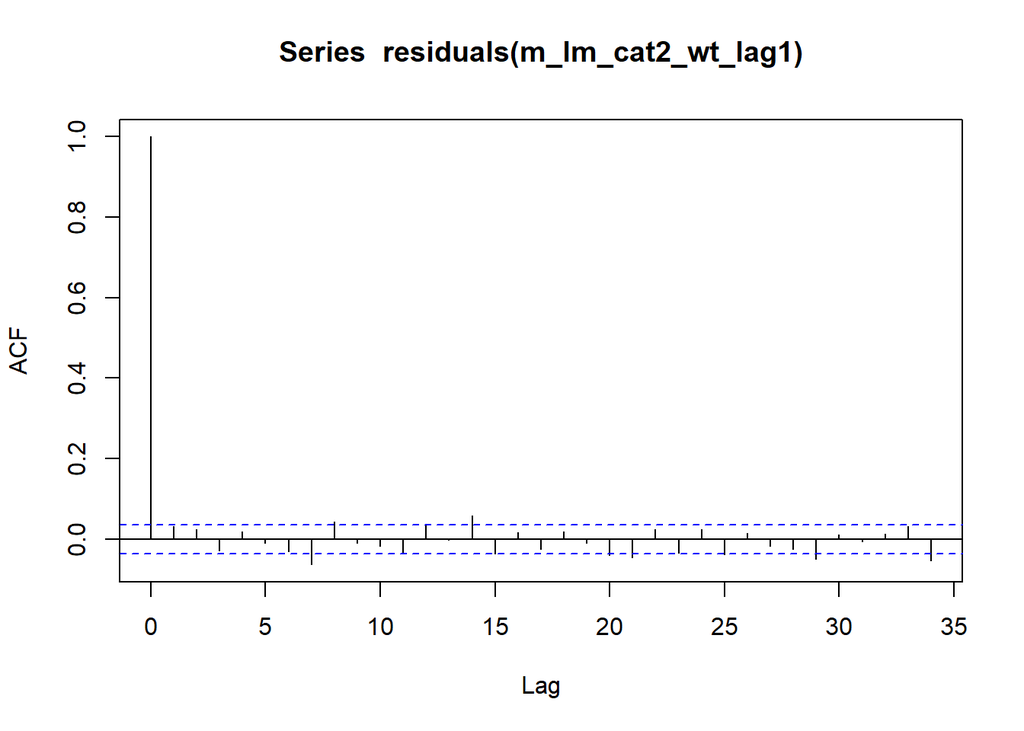

```r
m_lm_cat2_wt_lag1 <- df_chla_wt_lag %>%
  drop_na(Chla_log, WaterTemp, lag1) %>%
  lm(Chla_log ~ (Year_fct + FlowActionPeriod + StationCode)^2 + WaterTemp + lag1, data = .)

acf(residuals(m_lm_cat2_wt_lag1))
```

```r
Box.test(residuals(m_lm_cat2_wt_lag1), lag = 20, type = 'Ljung-Box')
```

```
##
##  Box-Ljung test
##
## data:  residuals(m_lm_cat2_wt_lag1)
## X-squared = 58.222, df = 20, p-value = 1.337e-05
```

#### Lag 2

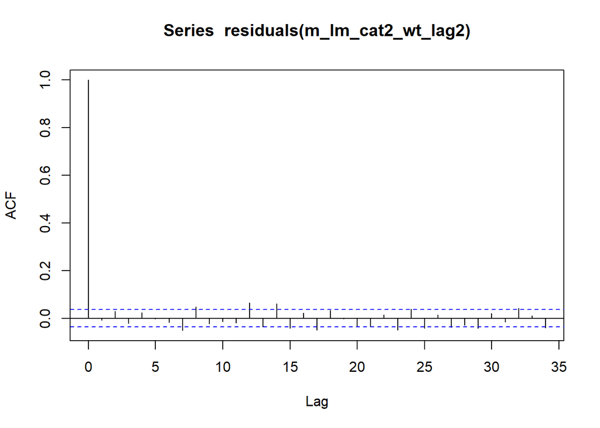

```r
m_lm_cat2_wt_lag2 <- df_chla_wt_lag %>%
  drop_na(Chla_log, WaterTemp, lag1, lag2) %>%
  lm(Chla_log ~ (Year_fct + FlowActionPeriod + StationCode)^2 + WaterTemp + lag1 + lag2, data = .)

acf(residuals(m_lm_cat2_wt_lag2))
```

```r
Box.test(residuals(m_lm_cat2_wt_lag2), lag = 20, type = 'Ljung-Box')
```

```
##
##  Box-Ljung test
##
## data:  residuals(m_lm_cat2_wt_lag2)
## X-squared = 70.972, df = 20, p-value = 1.263e-07
```

#### Lag 3

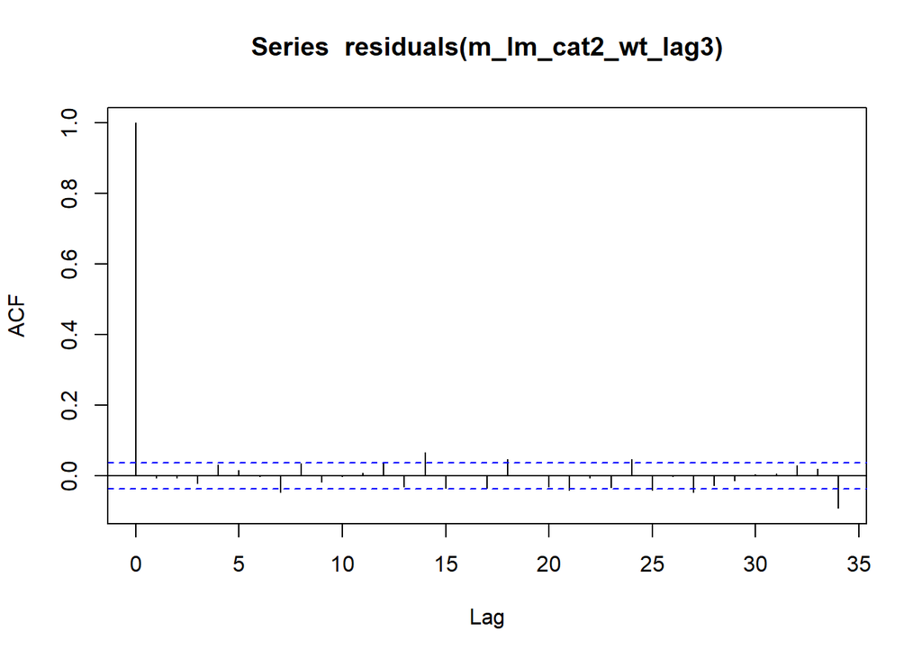

```r
m_lm_cat2_wt_lag3 <- df_chla_wt_lag %>%
  drop_na(Chla_log, WaterTemp, lag1, lag2, lag3) %>%
  lm(Chla_log ~ (Year_fct + FlowActionPeriod + StationCode)^2 + WaterTemp + lag1 + lag2 + lag3, data = .)

acf(residuals(m_lm_cat2_wt_lag3))
```

```r
Box.test(residuals(m_lm_cat2_wt_lag3), lag = 20, type = 'Ljung-Box')
```

```
##
##  Box-Ljung test
##
## data:  residuals(m_lm_cat2_wt_lag3)
## X-squared = 51.51, df = 20, p-value = 0.0001342
```

The model with 3 lag terms looks to have slightly better ACF and Box-Ljung test results than the model with 1 lag term. Let’s compare the 3 models using AIC and BIC to see which model those prefer.

#### Compare models

```r
AIC(m_lm_cat2_wt_lag1, m_lm_cat2_wt_lag2, m_lm_cat2_wt_lag3)
```

```
##                   df       AIC
## m_lm_cat2_wt_lag1 51 -2211.062
## m_lm_cat2_wt_lag2 52 -2170.794
## m_lm_cat2_wt_lag3 53 -2130.150
```

```r
BIC(m_lm_cat2_wt_lag1, m_lm_cat2_wt_lag2, m_lm_cat2_wt_lag3)
```

```
##                   df       BIC
## m_lm_cat2_wt_lag1 51 -1906.607
## m_lm_cat2_wt_lag2 52 -1861.021
## m_lm_cat2_wt_lag3 53 -1815.092
```

Both AIC and BIC prefer the model with 1 lag term. Let’s take a closer look at that one.

### Lag 1 model summary

```r
summary(m_lm_cat2_wt_lag1)
```

```
##
## Call:
## lm(formula = Chla_log ~ (Year_fct + FlowActionPeriod + StationCode)^2 +
##     WaterTemp + lag1, data = .)
##
## Residuals:
##      Min       1Q   Median       3Q      Max
## -1.65329 -0.05723 -0.00618  0.04969  1.32146
##
## Coefficients:
##                                         Estimate Std. Error t value Pr(>|t|)
## (Intercept)                             1.191711   0.104387  11.416  < 2e-16
## Year_fct2014                           -0.089576   0.033321  -2.688 0.007225
## Year_fct2015                           -0.011064   0.033238  -0.333 0.739248
## Year_fct2016                           -0.054635   0.035234  -1.551 0.121100
## Year_fct2017                           -0.050797   0.033159  -1.532 0.125661
## Year_fct2018                           -0.038796   0.032919  -1.179 0.238689
## Year_fct2019                           -0.034912   0.033137  -1.054 0.292178
## FlowActionPeriodDuring                 -0.070377   0.028621  -2.459 0.013995
## FlowActionPeriodAfter                   0.028026   0.031660   0.885 0.376103
## StationCodeSTTD                        -0.148629   0.033741  -4.405 1.10e-05
## StationCodeLIB                         -0.263814   0.035030  -7.531 6.72e-14
## StationCodeRVB                         -0.289045   0.035073  -8.241 2.57e-16
## WaterTemp                               0.001135   0.002150   0.528 0.597647
## lag1                                    0.875941   0.008971  97.639  < 2e-16
## Year_fct2014:FlowActionPeriodDuring    -0.039124   0.033709  -1.161 0.245884
## Year_fct2015:FlowActionPeriodDuring    -0.036631   0.029396  -1.246 0.212812
## Year_fct2016:FlowActionPeriodDuring    -0.020959   0.033251  -0.630 0.528531
## Year_fct2017:FlowActionPeriodDuring     0.009967   0.032981   0.302 0.762512
## Year_fct2018:FlowActionPeriodDuring    -0.017099   0.030781  -0.555 0.578599
## Year_fct2019:FlowActionPeriodDuring    -0.032189   0.031554  -1.020 0.307764
## Year_fct2014:FlowActionPeriodAfter     -0.043399   0.029494  -1.471 0.141271
## Year_fct2015:FlowActionPeriodAfter     -0.026004   0.029250  -0.889 0.374067
## Year_fct2016:FlowActionPeriodAfter     -0.088595   0.032078  -2.762 0.005784
## Year_fct2017:FlowActionPeriodAfter     -0.064878   0.030044  -2.159 0.030899
## Year_fct2018:FlowActionPeriodAfter     -0.083066   0.030733  -2.703 0.006917
## Year_fct2019:FlowActionPeriodAfter     -0.025718   0.029442  -0.874 0.382458
## Year_fct2014:StationCodeSTTD            0.130814   0.037118   3.524 0.000431
## Year_fct2015:StationCodeSTTD           -0.012610   0.034173  -0.369 0.712157
## Year_fct2016:StationCodeSTTD            0.110179   0.037042   2.974 0.002960
```

[output cut: 63 more lines]

```
## Year_fct2017:StationCodeRVB
## Year_fct2018:StationCodeRVB
## Year_fct2019:StationCodeRVB
## FlowActionPeriodDuring:StationCodeSTTD ***
## FlowActionPeriodAfter:StationCodeSTTD
## FlowActionPeriodDuring:StationCodeLIB  ***
## FlowActionPeriodAfter:StationCodeLIB
## FlowActionPeriodDuring:StationCodeRVB  **
## FlowActionPeriodAfter:StationCodeRVB
## ---
## Signif. codes:  0 '***' 0.001 '**' 0.01 '*' 0.05 '.' 0.1 ' ' 1
##
## Residual standard error: 0.1636 on 2842 degrees of freedom
## Multiple R-squared:  0.9745, Adjusted R-squared:  0.974
## F-statistic:  2215 on 49 and 2842 DF,  p-value: < 2.2e-16
```

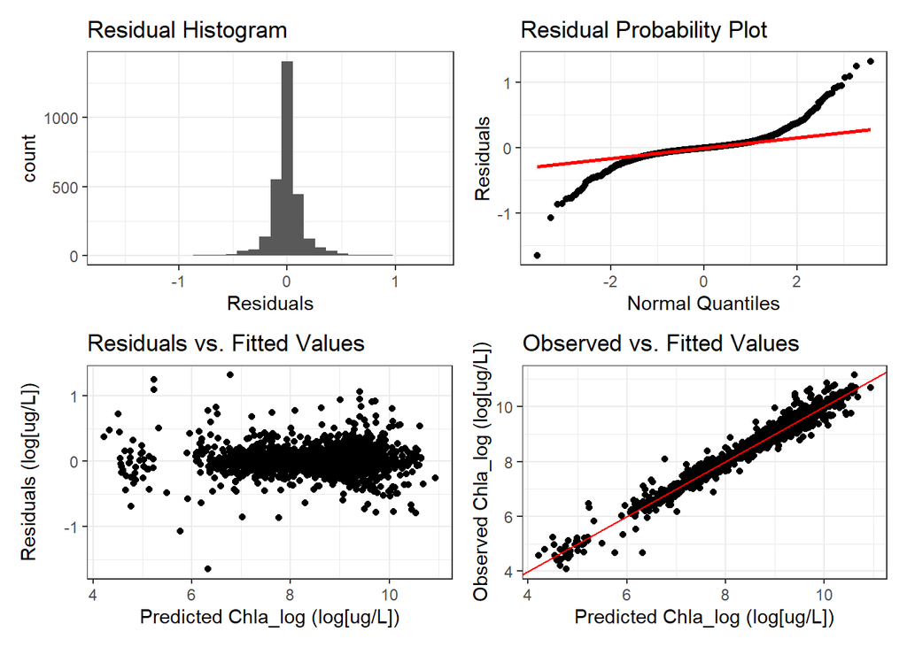

```r
df_chla_wt_lag %>%
  drop_na(Chla_log, WaterTemp, lag1) %>%
  plot_lm_diag(
    Chla_log,
    "ug/L",
    m_lm_cat2_wt_lag1,
    trans = "log"
  )
```

```r
shapiro.test(m_lm_cat2_wt_lag1$residuals)
```

```
##
##  Shapiro-Wilk normality test
##
## data:  m_lm_cat2_wt_lag1$residuals
## W = 0.82111, p-value < 2.2e-16
```

Hmmm, the residuals deviate from a normal distribution particularly at the both tails of the distribution. I’m not so sure about using this model. Let’s take a look at its ANOVA table using type 3 sum of squares.

```r
Anova(m_lm_cat2_wt_lag1, type = 3, contrasts = list(topic = contr.sum, sys = contr.sum))
```

```
## Anova Table (Type III tests)
##
## Response: Chla_log
##                               Sum Sq   Df   F value    Pr(>F)
## (Intercept)                    3.490    1  130.3319 < 2.2e-16 ***
## Year_fct                       0.305    6    1.8963 0.0777883 .
## FlowActionPeriod               0.404    2    7.5440 0.0005399 ***
## StationCode                    1.947    3   24.2426 1.735e-15 ***
## WaterTemp                      0.007    1    0.2786 0.5976472
## lag1                         255.265    1 9533.3675 < 2.2e-16 ***
## Year_fct:FlowActionPeriod      0.650   12    2.0224 0.0190524 *
## Year_fct:StationCode           3.076   18    6.3821 8.929e-16 ***
## FlowActionPeriod:StationCode   1.964    6   12.2279 1.262e-13 ***
## Residuals                     76.097 2842
## ---
## Signif. codes:  0 '***' 0.001 '**' 0.01 '*' 0.05 '.' 0.1 ' ' 1
```

All the interaction terms are significant, so we can use this model in our model selection process; however, I’m somewhat leery of using this model since the model residuals don’t look right and the water temperature term isn’t significant.

```r
rm(m_lm_cat2_wt, m_lm_cat2_wt_lag2, m_lm_cat2_wt_lag3)
```

## Model 6: LM 2-way interactions without seasonal term

### Initial Model

We’ll try running a linear model using all two-way interactions between Year, Flow Action Period, and Station without including a term to account for seasonality. First we’ll run the linear model without accounting for serial autocorrelation.

```r
m_lm_cat2 <- df_chla_wt_lag %>%
  drop_na(Chla_log) %>%
  lm(Chla_log ~ (Year_fct + FlowActionPeriod + StationCode)^2, data = .)
```

Lets look at the model summary and diagnostics:

```r
summary(m_lm_cat2)
```

```
##
## Call:
## lm(formula = Chla_log ~ (Year_fct + FlowActionPeriod + StationCode)^2,
##     data = .)
##
## Residuals:
##      Min       1Q   Median       3Q      Max
## -1.23917 -0.20797 -0.01003  0.18141  1.59954
##
## Coefficients:
##                                        Estimate Std. Error t value Pr(>|t|)
## (Intercept)                             9.72909    0.05993 162.332  < 2e-16 ***
## Year_fct2014                           -0.54396    0.06742  -8.069 1.03e-15 ***
## Year_fct2015                            0.03685    0.06794   0.542 0.587604
## Year_fct2016                           -0.21205    0.07150  -2.966 0.003045 **
## Year_fct2017                           -0.15756    0.06735  -2.339 0.019386 *
## Year_fct2018                           -0.22989    0.06719  -3.422 0.000631 ***
## Year_fct2019                           -0.25859    0.06717  -3.850 0.000121 ***
## FlowActionPeriodDuring                 -0.51916    0.05715  -9.084  < 2e-16 ***
## FlowActionPeriodAfter                   0.15654    0.05490   2.851 0.004385 **
## StationCodeSTTD                        -1.11036    0.06611 -16.795  < 2e-16 ***
## StationCodeLIB                         -2.11223    0.05969 -35.389  < 2e-16 ***
## StationCodeRVB                         -2.25084    0.05854 -38.450  < 2e-16 ***
## Year_fct2014:FlowActionPeriodDuring    -0.38921    0.06883  -5.655 1.71e-08 ***
## Year_fct2015:FlowActionPeriodDuring    -0.25461    0.06017  -4.231 2.40e-05 ***
## Year_fct2016:FlowActionPeriodDuring    -0.31300    0.06757  -4.632 3.78e-06 ***
## Year_fct2017:FlowActionPeriodDuring    -0.26051    0.06764  -3.851 0.000120 ***
## Year_fct2018:FlowActionPeriodDuring    -0.12634    0.06315  -2.001 0.045514 *
## Year_fct2019:FlowActionPeriodDuring    -0.26402    0.06459  -4.088 4.47e-05 ***
## Year_fct2014:FlowActionPeriodAfter     -0.43149    0.05866  -7.356 2.46e-13 ***
## Year_fct2015:FlowActionPeriodAfter     -0.31598    0.05947  -5.313 1.16e-07 ***
## Year_fct2016:FlowActionPeriodAfter     -0.64009    0.06079 -10.529  < 2e-16 ***
## Year_fct2017:FlowActionPeriodAfter     -0.66061    0.06037 -10.943  < 2e-16 ***
## Year_fct2018:FlowActionPeriodAfter     -0.65331    0.06145 -10.632  < 2e-16 ***
## Year_fct2019:FlowActionPeriodAfter     -0.23425    0.06019  -3.892 0.000102 ***
## Year_fct2014:StationCodeSTTD            0.90351    0.07475  12.087  < 2e-16 ***
## Year_fct2015:StationCodeSTTD           -0.26118    0.07051  -3.704 0.000216 ***
## Year_fct2016:StationCodeSTTD            0.69668    0.07547   9.232  < 2e-16 ***
## Year_fct2017:StationCodeSTTD            0.24158    0.08299   2.911 0.003629 **
## Year_fct2018:StationCodeSTTD           -0.51797    0.07319  -7.077 1.84e-12 ***
```

[output cut: 10 more lines]

```
## Year_fct2017:StationCodeRVB             0.29718    0.06789   4.377 1.24e-05 ***
## Year_fct2018:StationCodeRVB             0.28667    0.06642   4.316 1.64e-05 ***
## Year_fct2019:StationCodeRVB            -0.24807    0.06688  -3.709 0.000212 ***
## FlowActionPeriodDuring:StationCodeSTTD  1.51157    0.05088  29.706  < 2e-16 ***
## FlowActionPeriodAfter:StationCodeSTTD   0.23411    0.04635   5.051 4.67e-07 ***
## FlowActionPeriodDuring:StationCodeLIB   0.79121    0.04878  16.220  < 2e-16 ***
## FlowActionPeriodAfter:StationCodeLIB   -0.09403    0.04234  -2.221 0.026453 *
## FlowActionPeriodDuring:StationCodeRVB   0.52855    0.04676  11.303  < 2e-16 ***
## FlowActionPeriodAfter:StationCodeRVB   -0.05663    0.04074  -1.390 0.164610
## ---
## Signif. codes:  0 '***' 0.001 '**' 0.01 '*' 0.05 '.' 0.1 ' ' 1
##
## Residual standard error: 0.3408 on 2884 degrees of freedom
## Multiple R-squared:  0.8888, Adjusted R-squared:  0.887
## F-statistic: 490.7 on 47 and 2884 DF,  p-value: < 2.2e-16
```

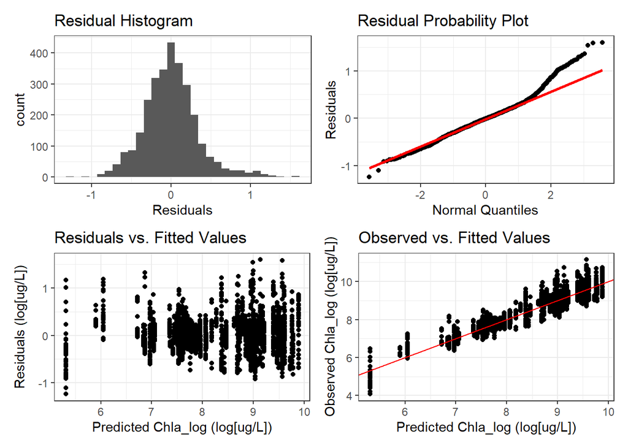

```r
df_chla_wt_lag %>%
  drop_na(Chla_log) %>%
  plot_lm_diag(
    Chla_log,
    "ug/L",
    m_lm_cat2,
    trans = "log"
  )
```

```r
shapiro.test(m_lm_cat2$residuals)
```

```
##
##  Shapiro-Wilk normality test
##
## data:  m_lm_cat2$residuals
## W = 0.97416, p-value < 2.2e-16
```

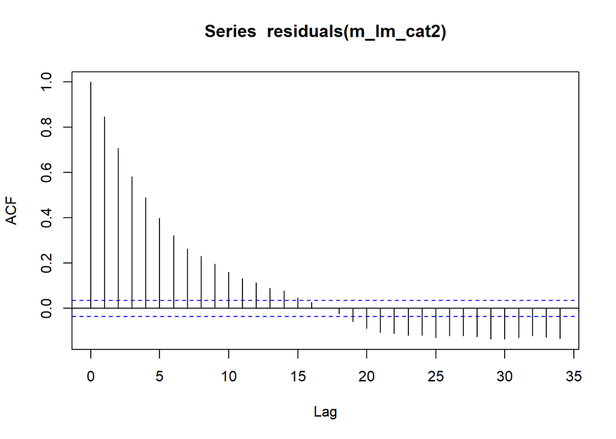

```r
acf(residuals(m_lm_cat2))
```

```r
Box.test(residuals(m_lm_cat2), lag = 20, type = 'Ljung-Box')
```

```
##
##  Box-Ljung test
##
## data:  residuals(m_lm_cat2)
## X-squared = 6777.5, df = 20, p-value < 2.2e-16
```

Hmmm, the residuals deviate from a normal distribution according to visual inspection and the Shapiro-Wilk normality test. Also, the residuals are autocorrelated.

### Model with lag terms

Now, we’ll try to deal with the residual autocorrelation and the non-normal residuals. We’ll run a series of linear models adding 1, 2, and 3 lag terms and compare how well they correct for autocorrelation.

#### Lag 1

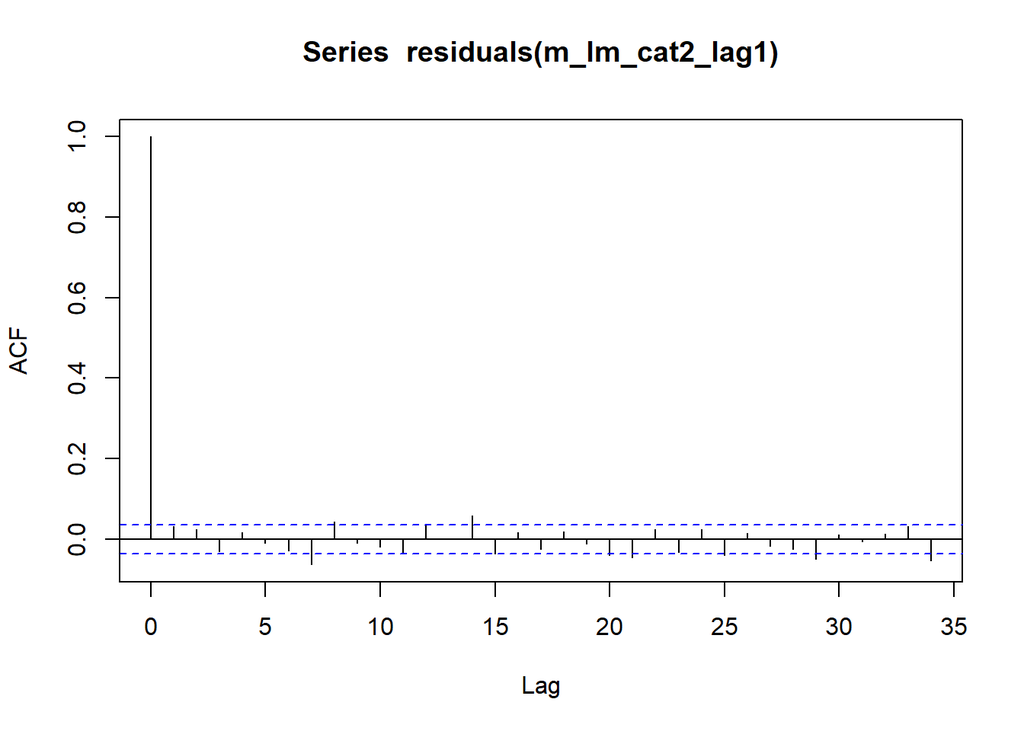

```r
m_lm_cat2_lag1 <- df_chla_wt_lag %>%
  drop_na(Chla_log, lag1) %>%
  lm(Chla_log ~ (Year_fct + FlowActionPeriod + StationCode)^2 + lag1, data = .)

acf(residuals(m_lm_cat2_lag1))
```

```r
Box.test(residuals(m_lm_cat2_lag1), lag = 20, type = 'Ljung-Box')
```

```
##
##  Box-Ljung test
##
## data:  residuals(m_lm_cat2_lag1)
## X-squared = 58.272, df = 20, p-value = 1.314e-05
```

#### Lag 2

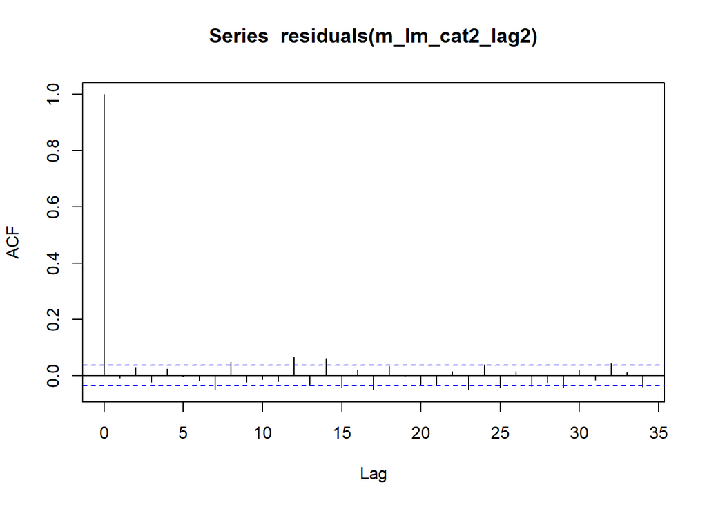

```r
m_lm_cat2_lag2 <- df_chla_wt_lag %>%
  drop_na(Chla_log, lag1, lag2) %>%
  lm(Chla_log ~ (Year_fct + FlowActionPeriod + StationCode)^2 + lag1 + lag2, data = .)

acf(residuals(m_lm_cat2_lag2))
```

```r
Box.test(residuals(m_lm_cat2_lag2), lag = 20, type = 'Ljung-Box')
```

```
##
##  Box-Ljung test
##
## data:  residuals(m_lm_cat2_lag2)
## X-squared = 70.963, df = 20, p-value = 1.267e-07
```

#### Lag 3

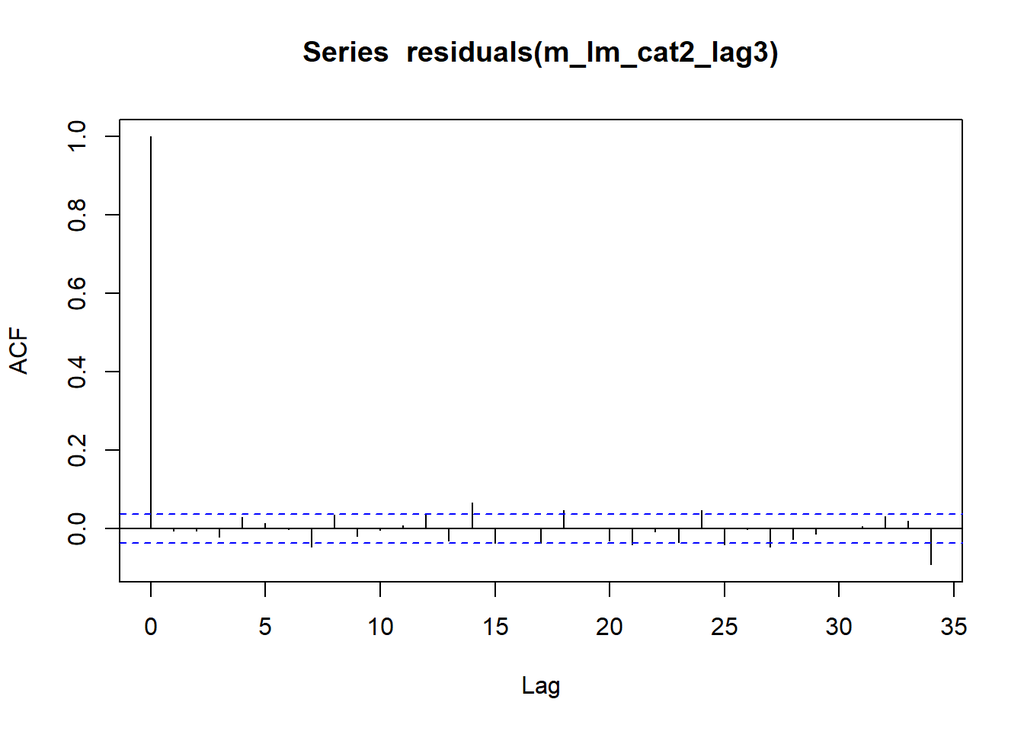

```r
m_lm_cat2_lag3 <- df_chla_wt_lag %>%
  drop_na(Chla_log, lag1, lag2, lag3) %>%
  lm(Chla_log ~ (Year_fct + FlowActionPeriod + StationCode)^2 + lag1 + lag2 + lag3, data = .)

acf(residuals(m_lm_cat2_lag3))
```

```r
Box.test(residuals(m_lm_cat2_lag3), lag = 20, type = 'Ljung-Box')
```

```
##
##  Box-Ljung test
##
## data:  residuals(m_lm_cat2_lag3)
## X-squared = 51.531, df = 20, p-value = 0.0001332
```

The model with 3 lag terms looks to have slightly better ACF and Box-Ljung test results than the model with 1 lag term. Let’s compare the 3 models using AIC and BIC to see which model those prefer.

#### Compare models

```r
AIC(m_lm_cat2_lag1, m_lm_cat2_lag2, m_lm_cat2_lag3)
```

```
##                df       AIC
## m_lm_cat2_lag1 50 -2218.889
## m_lm_cat2_lag2 51 -2178.457
## m_lm_cat2_lag3 52 -2137.377
```

```r
BIC(m_lm_cat2_lag1, m_lm_cat2_lag2, m_lm_cat2_lag3)
```

```
##                df       BIC
## m_lm_cat2_lag1 50 -1920.334
## m_lm_cat2_lag2 51 -1874.570
## m_lm_cat2_lag3 52 -1828.190
```

Both AIC and BIC prefer the model with 1 lag term. Let’s take a closer look at that one.

### Lag 1 model summary

```r
summary(m_lm_cat2_lag1)
```

```
##
## Call:
## lm(formula = Chla_log ~ (Year_fct + FlowActionPeriod + StationCode)^2 +
##     lag1, data = .)
##
## Residuals:
##      Min       1Q   Median       3Q      Max
## -1.65247 -0.05772 -0.00654  0.04937  1.31988
##
## Coefficients:
##                                         Estimate Std. Error t value Pr(>|t|)
## (Intercept)                             1.216102   0.092117  13.202  < 2e-16
## Year_fct2014                           -0.088344   0.033278  -2.655 0.007981
## Year_fct2015                           -0.009516   0.033158  -0.287 0.774134
## Year_fct2016                           -0.051913   0.034969  -1.485 0.137771
## Year_fct2017                           -0.048184   0.032910  -1.464 0.143268
## Year_fct2018                           -0.038091   0.032891  -1.158 0.246923
## Year_fct2019                           -0.032346   0.032904  -0.983 0.325669
## FlowActionPeriodDuring                 -0.072114   0.028315  -2.547 0.010921
## FlowActionPeriodAfter                   0.020326   0.026837   0.757 0.448887
## StationCodeSTTD                        -0.149099   0.033701  -4.424 1.00e-05
## StationCodeLIB                         -0.264370   0.034736  -7.611 3.68e-14
## StationCodeRVB                         -0.290098   0.034937  -8.303  < 2e-16
## lag1                                    0.876122   0.008961  97.774  < 2e-16
## Year_fct2014:FlowActionPeriodDuring    -0.038814   0.033673  -1.153 0.249140
## Year_fct2015:FlowActionPeriodDuring    -0.036636   0.029373  -1.247 0.212412
## Year_fct2016:FlowActionPeriodDuring    -0.018906   0.032956  -0.574 0.566237
## Year_fct2017:FlowActionPeriodDuring     0.010850   0.032896   0.330 0.741560
## Year_fct2018:FlowActionPeriodDuring    -0.017809   0.030748  -0.579 0.562510
## Year_fct2019:FlowActionPeriodDuring    -0.032701   0.031529  -1.037 0.299748
## Year_fct2014:FlowActionPeriodAfter     -0.042201   0.028798  -1.465 0.142926
## Year_fct2015:FlowActionPeriodAfter     -0.025477   0.029063  -0.877 0.380767
## Year_fct2016:FlowActionPeriodAfter     -0.083856   0.030153  -2.781 0.005454
## Year_fct2017:FlowActionPeriodAfter     -0.065266   0.029978  -2.177 0.029551
## Year_fct2018:FlowActionPeriodAfter     -0.082123   0.030463  -2.696 0.007063
## Year_fct2019:FlowActionPeriodAfter     -0.027320   0.029381  -0.930 0.352516
## Year_fct2014:StationCodeSTTD            0.130915   0.037089   3.530 0.000422
## Year_fct2015:StationCodeSTTD           -0.013397   0.034117  -0.393 0.694580
## Year_fct2016:StationCodeSTTD            0.108933   0.036949   2.948 0.003222
## Year_fct2017:StationCodeSTTD            0.082475   0.040482   2.037 0.041710
```

[output cut: 61 more lines]

```
## Year_fct2017:StationCodeRVB
## Year_fct2018:StationCodeRVB
## Year_fct2019:StationCodeRVB
## FlowActionPeriodDuring:StationCodeSTTD ***
## FlowActionPeriodAfter:StationCodeSTTD
## FlowActionPeriodDuring:StationCodeLIB  ***
## FlowActionPeriodAfter:StationCodeLIB
## FlowActionPeriodDuring:StationCodeRVB  **
## FlowActionPeriodAfter:StationCodeRVB
## ---
## Signif. codes:  0 '***' 0.001 '**' 0.01 '*' 0.05 '.' 0.1 ' ' 1
##
## Residual standard error: 0.1635 on 2847 degrees of freedom
## Multiple R-squared:  0.9745, Adjusted R-squared:  0.9741
## F-statistic:  2265 on 48 and 2847 DF,  p-value: < 2.2e-16
```

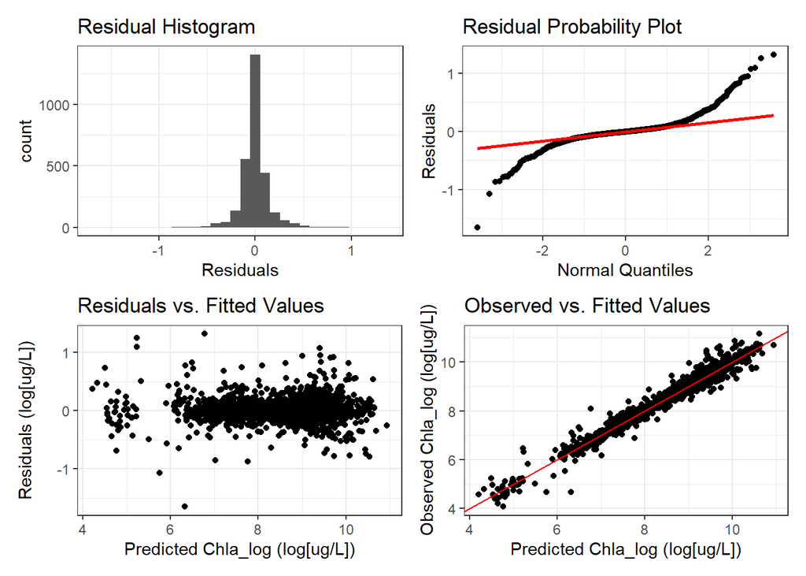

```r
df_chla_wt_lag %>%
  drop_na(Chla_log, lag1) %>%
  plot_lm_diag(
    Chla_log,
    "ug/L",
    m_lm_cat2_lag1,
    trans = "log"
  )
```

```r
shapiro.test(m_lm_cat2_lag1$residuals)
```

```
##
##  Shapiro-Wilk normality test
##
## data:  m_lm_cat2_lag1$residuals
## W = 0.82107, p-value < 2.2e-16
```

Hmmm, again the residuals deviate from a normal distribution particularly at the both tails of the distribution. I’m not so sure about using this model. Let’s take a look at its ANOVA table using type 3 sum of squares.

```r
Anova(m_lm_cat2_lag1, type = 3, contrasts = list(topic = contr.sum, sys = contr.sum))
```

```
## Anova Table (Type III tests)
##
## Response: Chla_log
##                               Sum Sq   Df   F value    Pr(>F)
## (Intercept)                    4.661    1  174.2870 < 2.2e-16 ***
## Year_fct                       0.301    6    1.8764 0.0811165 .
## FlowActionPeriod               0.428    2    8.0014 0.0003426 ***
## StationCode                    1.981    3   24.6957 9.017e-16 ***
## lag1                         255.643    1 9559.7382 < 2.2e-16 ***
## Year_fct:FlowActionPeriod      0.654   12    2.0381 0.0179620 *
## Year_fct:StationCode           3.065   18    6.3671 9.975e-16 ***
## FlowActionPeriod:StationCode   1.958    6   12.2005 1.360e-13 ***
## Residuals                     76.133 2847
## ---
## Signif. codes:  0 '***' 0.001 '**' 0.01 '*' 0.05 '.' 0.1 ' ' 1
```

All the interaction terms are significant, so we can use this model in our model selection process; however, I’m somewhat leery of using this model since the model residuals don’t look right.

```r
rm(m_lm_cat2, m_lm_cat2_lag2, m_lm_cat2_lag3)
```

# Model selection - GAM and LM models

As a summary, here are the 6 models we are comparing:

- Model 1 - `m_gamm_cat3_ar1` - GAM 3-way interactions with s(DOY)  
  Formula: Chla_log ~ Year_fct * FlowActionPeriod * StationCode + s(DOY, k = 5)
- Model 2 - `m_lm_cat3_wt_lag1` - LM 3-way interactions with water temperature  
  Formula: Chla_log ~ Year_fct * FlowActionPeriod * StationCode + WaterTemp + lag1
- Model 3 - `m_lm_cat3_lag1` - LM 3-way interactions without seasonal term  
  Formula: Chla_log ~ Year_fct * FlowActionPeriod * StationCode + lag1
- Model 4 - `m_gamm_cat2_ar1` - GAM 2-way interactions with s(DOY)  
  Formula: Chla_log ~ (Year_fct + FlowActionPeriod + StationCode)^2 + s(DOY, k = 5)
- Model 5 - `m_lm_cat2_wt_lag1` - LM 2-way interactions with water temperature  
  Formula: Chla_log ~ (Year_fct + FlowActionPeriod + StationCode)^2 + WaterTemp + lag1
- Model 6 - `m_lm_cat2_lag1` - LM 2-way interactions without seasonal term  
  Formula: Chla_log ~ (Year_fct + FlowActionPeriod + StationCode)^2 + lag1

```r
# AIC values
df_m_aic <-
  AIC(
    m_gamm_cat3_ar1$lme,
    m_lm_cat3_wt_lag1,
    m_lm_cat3_lag1,
    m_gamm_cat2_ar1$lme,
    m_lm_cat2_wt_lag1,
    m_lm_cat2_lag1
  ) %>%
  as_tibble(rownames = "Model")

# BIC values
df_m_bic <-
  BIC(
    m_gamm_cat3_ar1$lme,
    m_lm_cat3_wt_lag1,
    m_lm_cat3_lag1,
    m_gamm_cat2_ar1$lme,
    m_lm_cat2_wt_lag1,
    m_lm_cat2_lag1
  ) %>%
  as_tibble(rownames = "Model")

# Combine AIC and BIC
df_m_aic_bic <- left_join(df_m_aic, df_m_bic, by = join_by(Model, df))

# Sort by AIC
df_m_aic_bic %>% arrange(AIC)
```

```
## # A tibble: 6 × 4
##   Model                  df    AIC    BIC
##   <chr>               <dbl>  <dbl>  <dbl>
## 1 m_lm_cat3_lag1         86 -2244. -1731.
## 2 m_lm_cat3_wt_lag1      87 -2236. -1717.
## 3 m_lm_cat2_lag1         50 -2219. -1920.
## 4 m_lm_cat2_wt_lag1      51 -2211. -1907.
## 5 m_gamm_cat3_ar1$lme    88 -1932. -1408.
## 6 m_gamm_cat2_ar1$lme    52 -1908. -1598.
```

```r
# Sort by BIC
df_m_aic_bic %>% arrange(BIC)
```

```
## # A tibble: 6 × 4
##   Model                  df    AIC    BIC
##   <chr>               <dbl>  <dbl>  <dbl>
## 1 m_lm_cat2_lag1         50 -2219. -1920.
## 2 m_lm_cat2_wt_lag1      51 -2211. -1907.
## 3 m_lm_cat3_lag1         86 -2244. -1731.
## 4 m_lm_cat3_wt_lag1      87 -2236. -1717.
## 5 m_gamm_cat2_ar1$lme    52 -1908. -1598.
## 6 m_gamm_cat3_ar1$lme    88 -1932. -1408.
```

According to AIC, model 3 (LM 3-way interactions without seasonal term) was the best model, while BIC preferred model 6 (LM 2-way interactions without seasonal term). We’ll select model 3 (LM 3-way interactions without seasonal term) because the 3-way interaction between categorical variables was significant in this model indicating that there are possible significant differences between Flow Pulse Periods within each Station-Year grouping. We’ll export model 3 and its data to be used for further exploration in other notebooks.

```r
# Define file path for model and data used in the model
fp_model <- here("manuscript_synthesis/model")

# Export model and data used in the model
m_lm_cat3_lag1 %>% saveRDS(file.path(fp_model, "chla_cat3_lm_model.rds"))

df_chla_wt_lag %>%
  select(StationCode, Year, Date, Chla, Chla_log, FlowActionPeriod, lag1) %>%
  drop_na(Chla_log, lag1) %>%
  saveRDS(file.path(fp_model, "chla_model_data.rds"))
```